# Project Final Submission Template

### Step 1a: Planning

#### Identify the information in the file your program will read

About the song:

- Title of the song
- Artist who created the song
- Year song was released
- Popularity: **It is unclear what the popularity exactly represents, as they are represented as floats. However, since they are to 9 decimal places, it will be assumed that popularity is represented as views in billions. Also, some place "NaN" as the popularity. Some popularities are 0.**
- Duration of the song in seconds
- Tempo of the song is beats per minute

As "NaN" is a non-float type, it is unreliable as a popularity, thus rows with "NaN" for popularity may be skipped. Popularities of 0 most likely occur due to a very low value in popularity (eg: 0.000000100), but will not be marked as unreliable, as they still portray that the popularity was extremely low, which is still useful information.

### Step 1b: Planning

#### Brainstorm ideas for what your program will produce

#### Select the idea you will build on for subsequent steps

The objective of the program is to produce a graph that illustrates how the tempo of songs have evolved over time. This can be done in three different ways:

1. Display the relationship between tempo (bpm) and popularity throughout time, represented by a scatterplot. Each point will represent a decade and will be plotted in a plane with tempo and popularity on the axis, derived by computing the average popularity and tempos of all songs in a given decade, and repeating for each decade (that of which represents each point). If possible, each point (which represents a particular decade) will be coloured differently to help see the change over time.
2. Display the distribution of tempos and their popularity through a histogram by creating intervals of tempos (eg: 100-110bpm, 110-120bpm) and calculating the average popularities of songs given the interval of tempos.
3. Similiar to the output of 1, graph how popularities of certain tempos have changed over time through a line chart. The process in doing so will be similar to 2 in that first, the program would filter all the rows with certain bpms (eg: 100-110bpm, 110-120bpm), representing the line itself, and place it on a plane with time on its x-axis and popularity on the y-axis. Then, for each year, plot the average popularities of all songs for the given year. The process will be repeated for other tempos, creating a line chart with multiple lines.

The chosen program will be the one described in 3.

### Step 1c: Planning

#### Write or draw examples of what your program will produce

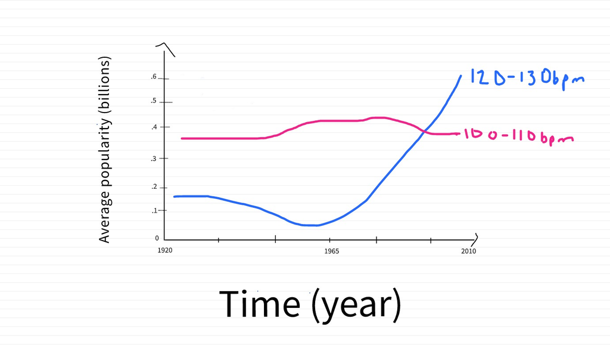

### Step 2a: Building

#### Document which information you will represent in your data definitions

#### Design data definitions

The programs objective is to display how popularity of certain tempos have changed over time, ultimately represented by a line graph. The graph requires three variables: time (given in year), popularity (given in units of billion views) and tempo (given in bpm). The data definition for compound will consist of those three fields: year, popularity and tempo.

```python
from cs103 import *
from typing import NamedTuple, List
import csv

##################
# Data Definitions

SongData = NamedTuple("SongData", [("year", int), # in range (0, ...)
                                   ("popularity", float), # in range [0, ...)
                                   ("tempo", float)]) # in range [0, ...)
# interp. the attributes of a song: the title of the song (title), the year it was released (year),
# its popularity in units of billion views, and its tempo in bpm.

SD1 = SongData(2009, 0.355285536, 139.94)
SD2 = SongData(1973, 0.487112195, 80.29)
SD3 = SongData(2001, 0.572983739, 100.23)
SD4 = SongData(2010, 0.284309293, 109.99)
SD5 = SongData(2009, 0.793812398, 83.23)
SD6 = SongData(1973, 0.982437823, 85.67)
SD7 = SongData(2009, 0.827393833, 85.67)
SD8 = SongData(2009, 0.578439847, 89.99)
SD9 = SongData(2001, 0.578439847, 89.99)
SD10 = SongData(2009, 0.487112195, 132.29)
SD11 = SongData(1999, 0.538929309, 135.55)
SD12 = SongData(1999, 0.538929309, 105.55)
SD13 = SongData(2002, 0.538929309, 145.55)
SD14 = SongData(2009, 0.638929309, 140.00)

# template based on Compound
@typecheck
def fn_for_song_data(sd: SongData) -> ...:
    return ...(sd.year,
               sd.popularity,
               sd.tempo)

##############################################################################################################

# List[SongData]
# interp. a list of SongData

LOSD0 = []
LOSD1 = [SD1]
LOSD2 = [SD1, SD2]
LOSD3 = [SD1, SD2, SD3]
LOSD4 = [SD1, SD2, SD3, SD4]
LOSD5 = [SD8, SD7, SD5] # all from 2009 and within bpm 80-90
LOSD6 = [SD1, SD2, SD3, SD4, SD5, SD6, SD7, SD8]
LOSD7 = [SD1, SD2, SD3, SD4, SD5, SD6, SD7, SD8,
         SD9, SD10, SD11, SD12, SD13, SD14]

# template based on arbitrary-sized data and reference rule
@typecheck
def fn_for_losd(losd: List[SongData]) -> ...:
    # description of accumulator
    acc = ...   # type: ...

    for sd in losd:
        acc = ...(fn_for_song_data(sd), acc)

    return ...(acc)

# or choose another template

# List[float]
# interp. a list of floats
LOS0 = []
LOS1 = [34.28, -23.2]

# template based on arbitrary-sized data
@typecheck
def fn_for_lof(lof: List[float]) -> ...:
    # description of accumulator
    acc = ... # type: ...

    for f in lof:
        acc = ...(f, acc)

    return ...(acc)

##############################################################################################################

# List[int]
# interp. a list of integers
LOI0 = []
LOI1 = [5, -4]

# template based on arbitrary-sized data
@typecheck
def fn_for_loi(loi: List[int]) -> ...:
    # description of accumulator
    acc = ... # type: ...

    for i in loi:
        acc = ...(i, acc)

    return ...(acc)

##############################################################################################################

# List[str]
# interp. a list of strings
LOS0 = []
LOS1 = ['cat', 'dog']

# template based on arbitrary-sized data
@typecheck
def fn_for_los(los: List[str]) -> ...:
    # description of accumulator
    acc = ... # type: ...

    for s in los:
        acc = ...(s, acc)

    return ...(acc)
```